# Under-5 Mortality: A Global Perspective

Author

Padmaja Huprikar(A00010704)

# 🌍 Introduction

Child mortality remains one of the most pressing global challenges. Where a lot of countries show utmost care around this area, there are certain countries which neglect this fact that children are the future of the world. This report explores trends and disparities in under-5 mortality across countries, continents, and genders using UNICEF data.

# 📊 Global Average Mortality Trend Over Time

The global average under-5 mortality rate across years, highlights an overall declining trend and reflects progress in healthcare access and maternal support.This is a good start for the new era of reducing the under-5 mortality rate across the globe.

```python
# ✅ Put all imports at the top
import pandas as pd
import polars as pl
from plotnine import *
```

```python
!pip install pycountry pycountry-convert > /dev/null 2>&1
```

[figure not shown]

```python
import polars as pl
from plotnine import ggplot, aes, geom_point, geom_smooth, labs, theme_minimal

# Load and prepare data in Polars
df = pl.read_csv("unicef_indicator_1.csv")
df = df.rename({col: col.strip() for col in df.columns})
df = df.filter(pl.col("indicator").str.to_lowercase().str.contains("mortality"))
df = df.drop_nulls(subset=["obs_value", "time_period", "country"])

# Group by year and calculate average mortality
avg_df = df.group_by("time_period").agg(
    pl.col("obs_value").mean().alias("avg_mortality")
).sort("time_period")

# Convert to pandas for plotnine
avg_df_pd = avg_df.to_pandas()
avg_df_pd["time_period"] = avg_df_pd["time_period"].astype(int)

# Plot with regression line
from plotnine import ggplot, aes, geom_point, geom_smooth, labs, theme_minimal

plot = (
    ggplot(avg_df_pd, aes(x="time_period", y="avg_mortality"))
    + geom_point(color="#0072B2", size=3)
    + geom_smooth(method="lm", se=True, color="red")
    + labs(
        title="Trend of Average Under-5 Mortality Rate Over Time",
        x="Year",
        y="Average Under-5 Mortality Rate"
    )
    + theme_minimal()
    + theme(
    plot_title=element_text(color='white'),
    axis_title_x=element_text(color='white'),
    axis_title_y=element_text(color='white'),
    axis_text_x=element_text(color='white'),
    axis_text_y=element_text(color='white'),
    legend_text=element_text(color='white'),
    legend_title=element_text(color='white')
)

)

plot
```

# 📊 Country Wise Mortality Trend for 2022

According to the data, the recent year statistics shows the country wise under-5 mortality wherein the darker shades indicate higher mortality rates, highlighting regions with urgent healthcare needs. Evidently, the African region is the highest in the mortality rate and this is a result of a lot of factors which are poor education, low income, unhealthy environment, less water sanitization, so on and so forth.

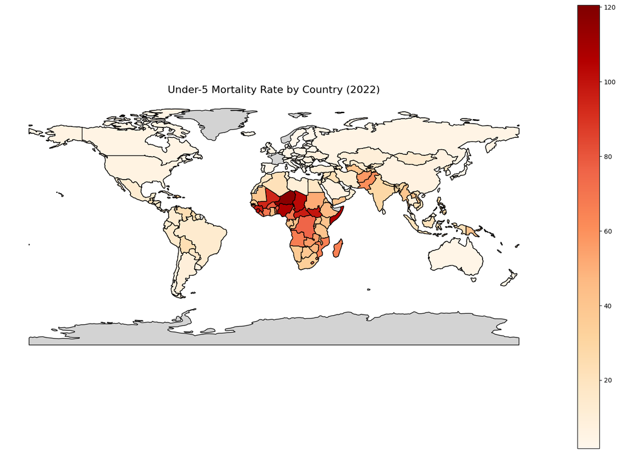

```python
import pandas as pd
import matplotlib.pyplot as plt

# Load UNICEF data
df = pd.read_csv("unicef_indicator_1.csv")

# Clean column names
df.columns = df.columns.str.strip()

# Filter for Under-5 mortality only
mortality_df = df[df["indicator"].str.contains("mortality", case=False)]

# Use most recent year (2022)
latest_year = mortality_df["time_period"].max()

# Filter for latest year
mortality_2022 = mortality_df[mortality_df["time_period"] == latest_year]

# Keep only relevant columns
mortality_2022 = mortality_2022[["alpha_3_code", "obs_value", "country"]].rename(
    columns={
        "alpha_3_code": "iso_a3",
        "obs_value": "under5_mortality",
        "country": "country_name"
    }
)

# Merge with shapefile GeoDataFrame
world_merged = world.merge(mortality_2022, how="left", left_on="ISO_A3", right_on="iso_a3")

# Plot
fig, ax = plt.subplots(1, 1, figsize=(15, 10))
world_merged.plot(
    column="under5_mortality",
    ax=ax,
    legend=True,
    cmap="OrRd",
    edgecolor="black",
    missing_kwds={
        "color": "lightgrey",
        "label": "No data"
    }
)

ax.set_title(f"Under-5 Mortality Rate by Country ({latest_year})", fontsize=16)
ax.axis("off")

plt.tight_layout()
plt.show()
```